# Ejercicio 9.5 de MPV

Freddy Hernández

4 May 2017

## Objetivo

En este ejercicio se busca encontrar un modelo de regresión lineal que explique la variable respuesta $y$ en función de las covariables presentadas en la tabla b3 del texto.

## Base de datos

A continuación se muestra el encabezado de la base de datos y la definición de las variables.

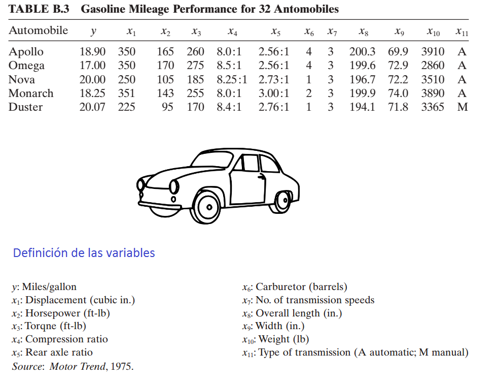

**Nota**: Type of transmission (1=automatic, 0=manual).

Antes de iniciar es necesario revisar si hay `NA's` y eliminarlos.

```r
require(MPV)
table.b3[22:26, ] # Can you see the missing values?
```

```
##        y    x1  x2  x3  x4   x5 x6 x7    x8   x9  x10 x11
## 22 21.47 360.0 180 290 8.4 2.45  2  3 214.2 76.3 4250   1
## 23 16.59 400.0 185  NA 7.6 3.08  4  3 196.0 73.0 3850   1
## 24 31.90  96.9  75  83 9.0 4.30  2  5 165.2 61.8 2275   0
## 25 29.40 140.0  86  NA 8.0 2.92  2  4 176.4 65.4 2150   0
## 26 13.27 460.0 223 366 8.0 3.00  4  3 228.0 79.8 5430   1
```

```r
datis <- table.b3[-c(23,25), ]
```

El objeto `datis` tiene la base de datos sin las líneas con `NA`, lo mismo se hubiese podido realizar usando la función `na.omit`.

## Diagramas de dispersión

A continuación se muestran los diagramas de dispersión para las variables de la base de datos.

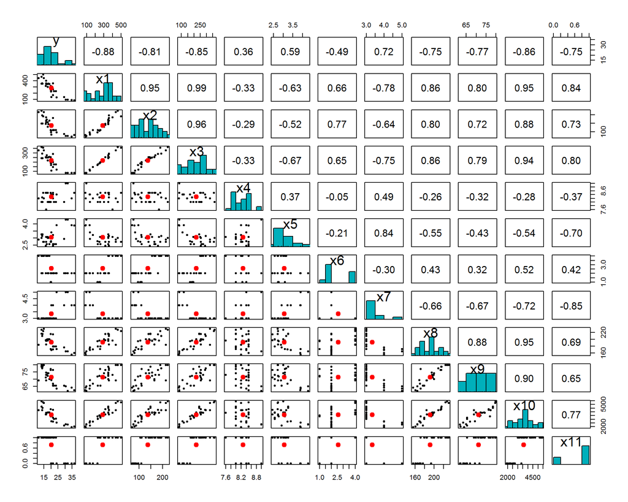

## Aplicación del método **backward**

Vamos a crear un modelo *saturado*.

```r
full.model <- lm(y ~ ., data = datis)
summary(full.model)
```

```
##
## Call:
## lm(formula = y ~ ., data = datis)
##
## Residuals:
##     Min      1Q  Median      3Q     Max
## -5.3441 -1.6711 -0.4486  1.4906  5.2508
##
## Coefficients:
##              Estimate Std. Error t value Pr(>|t|)
## (Intercept) 17.339838  30.355375   0.571   0.5749
## x1          -0.075588   0.056347  -1.341   0.1964
## x2          -0.069163   0.087791  -0.788   0.4411
## x3           0.115117   0.088113   1.306   0.2078
## x4           1.494737   3.101464   0.482   0.6357
## x5           5.843495   3.148438   1.856   0.0799 .
## x6           0.317583   1.288967   0.246   0.8082
## x7          -3.205390   3.109185  -1.031   0.3162
## x8           0.180811   0.130301   1.388   0.1822
## x9          -0.397945   0.323456  -1.230   0.2344
## x10         -0.005115   0.005896  -0.868   0.3971
## x11          0.638483   3.021680   0.211   0.8350
## ---
## Signif. codes:  0 '***' 0.001 '**' 0.01 '*' 0.05 '.' 0.1 ' ' 1
##
## Residual standard error: 3.227 on 18 degrees of freedom
## Multiple R-squared:  0.8355, Adjusted R-squared:  0.7349
## F-statistic:  8.31 on 11 and 18 DF,  p-value: 5.231e-05
```

De la tabla anterior se puede pensar en un efecto de enmascaramiento entre las variables.

Se usa la función `stepAIC` y se elije `trace=TRUE` para obtener detalles del proceso de selección.

```r
require(MASS)  # Para poder usar la función stepAIC
modback <- stepAIC(full.model, trace=TRUE, direction="backward")
```

```
## Start:  AIC=78.96
## y ~ x1 + x2 + x3 + x4 + x5 + x6 + x7 + x8 + x9 + x10 + x11
##
##        Df Sum of Sq    RSS    AIC
## - x11   1     0.465 187.87 77.036
## - x6    1     0.632 188.03 77.063
## - x4    1     2.418 189.82 77.346
## - x2    1     6.462 193.86 77.979
## - x10   1     7.836 195.24 78.190
## - x7    1    11.065 198.47 78.683
## <none>              187.40 78.962
## - x9    1    15.758 203.16 79.384
## - x3    1    17.770 205.17 79.679
## - x1    1    18.736 206.14 79.820
## - x8    1    20.047 207.45 80.011
## - x5    1    35.864 223.26 82.215
##
## Step:  AIC=77.04
## y ~ x1 + x2 + x3 + x4 + x5 + x6 + x7 + x8 + x9 + x10
##
##        Df Sum of Sq    RSS    AIC
## - x6    1     0.536 188.40 75.121
## - x4    1     2.363 190.23 75.411
## - x2    1     6.642 194.51 76.078
## - x10   1     7.985 195.85 76.285
## <none>              187.87 77.036
## - x7    1    14.124 201.99 77.211
## - x9    1    16.914 204.78 77.622
## - x3    1    17.815 205.68 77.754
## - x1    1    18.280 206.15 77.822
## - x8    1    20.301 208.17 78.114
## - x5    1    36.370 224.24 80.345
##
## Step:  AIC=75.12
## y ~ x1 + x2 + x3 + x4 + x5 + x7 + x8 + x9 + x10
##
##        Df Sum of Sq    RSS    AIC
## - x4    1     3.451 191.85 73.666
## - x2    1     6.932 195.33 74.205
## - x10   1     9.351 197.75 74.574
```

[output cut: 61 more lines]

```
##        Df Sum of Sq    RSS    AIC
## - x9    1     5.097 223.82 68.290
## <none>              218.73 69.599
## - x5    1    40.404 259.13 72.684
## - x8    1    57.407 276.13 74.591
## - x10   1   135.105 353.83 82.029
##
## Step:  AIC=68.29
## y ~ x5 + x8 + x10
##
##        Df Sum of Sq    RSS    AIC
## <none>              223.82 68.290
## - x5    1    36.314 260.14 70.800
## - x8    1    52.960 276.78 72.661
## - x10   1   194.838 418.66 85.076
```

Para obtener un resumen del proceso se usa:

```r
modback$anova
```

```
## Stepwise Model Path
## Analysis of Deviance Table
##
## Initial Model:
## y ~ x1 + x2 + x3 + x4 + x5 + x6 + x7 + x8 + x9 + x10 + x11
##
## Final Model:
## y ~ x5 + x8 + x10
##
##
##    Step Df   Deviance Resid. Df Resid. Dev      AIC
## 1                            18   187.4007 78.96155
## 2 - x11  1  0.4648362        19   187.8655 77.03587
## 3  - x6  1  0.5356445        20   188.4012 75.12128
## 4  - x4  1  3.4514854        21   191.8526 73.66591
## 5  - x2  1 10.7796848        22   202.6323 73.30587
## 6  - x7  1 10.4571693        23   213.0895 72.81545
## 7  - x3  1  4.8720101        24   217.9615 71.49363
## 8  - x1  1  0.7654631        25   218.7270 69.59881
## 9  - x9  1  5.0970905        26   223.8241 68.28989
```

Para ver la tabla de resultados del modelo `modback`.

```r
summary(modback)
```

```
##
## Call:
## lm(formula = y ~ x5 + x8 + x10, data = datis)
##
## Residuals:
##     Min      1Q  Median      3Q     Max
## -4.6101 -1.9868 -0.6613  2.0369  5.8811
##
## Coefficients:
##              Estimate Std. Error t value Pr(>|t|)
## (Intercept)  4.590404  11.771925   0.390   0.6998
## x5           2.597240   1.264562   2.054   0.0502 .
## x8           0.217814   0.087817   2.480   0.0199 *
## x10         -0.009485   0.001994  -4.757 6.38e-05 ***
## ---
## Signif. codes:  0 '***' 0.001 '**' 0.01 '*' 0.05 '.' 0.1 ' ' 1
##
## Residual standard error: 2.934 on 26 degrees of freedom
## Multiple R-squared:  0.8035, Adjusted R-squared:  0.7808
## F-statistic: 35.44 on 3 and 26 DF,  p-value: 2.462e-09
```

## Aplicación del método **forward**

Para aplicar este método se debe crear un modelo vacío (`empty.model`) del cual iniciará el proceso. Es necesario definir un punto final de búsqueda, ese punto es una formula que en este caso llamaremos `horizonte`. A continuación el código.

```r
empty.model <- lm(y ~ 1, data = datis)
horizonte <- formula(y ~ x1 + x2 + x3 + x4 + x5 + x6 + x7 + x8 + x9 + x10 + x11)
```

Se usa la función `stepAIC` y se elije `trace=FALSE` para que NO se muestren los detalles del proceso de selección.

```r
modforw <- stepAIC(empty.model, trace=FALSE, direction="forward", scope=horizonte)
modforw$anova
```

```
## Stepwise Model Path
## Analysis of Deviance Table
##
## Initial Model:
## y ~ 1
##
## Final Model:
## y ~ x1 + x4
##
##
##   Step Df  Deviance Resid. Df Resid. Dev       AIC
## 1                          29  1139.1050 111.10402
## 2 + x1  1 866.49528        28   272.6097  70.20532
## 3 + x4  1  18.57161        27   254.0381  70.08861
```

Para ver la tabla de resultados del modelo `modforw`.

```r
summary(modforw)
```

```
##
## Call:
## lm(formula = y ~ x1 + x4, data = datis)
##
## Residuals:
##     Min      1Q  Median      3Q     Max
## -6.5011 -2.1243 -0.3884  1.9964  6.9582
##
## Coefficients:
##              Estimate Std. Error t value Pr(>|t|)
## (Intercept)  7.179421  18.787955   0.382    0.705
## x1          -0.044479   0.005225  -8.513 3.98e-09 ***
## x4           3.077228   2.190294   1.405    0.171
## ---
## Signif. codes:  0 '***' 0.001 '**' 0.01 '*' 0.05 '.' 0.1 ' ' 1
##
## Residual standard error: 3.067 on 27 degrees of freedom
## Multiple R-squared:  0.777,  Adjusted R-squared:  0.7605
## F-statistic: 47.03 on 2 and 27 DF,  p-value: 1.594e-09
```

Como la variable $x_4$ no es significativa entonces se puede refinar o actualizar el modelo `modforw` sacando $x_4$, esto se puede realizar fácilmente por medio de la función `update` así:

```r
modforw <- update(modforw, y ~ x1)
summary(modforw)
```

```
##
## Call:
## lm(formula = y ~ x1, data = datis)
##
## Residuals:
##     Min      1Q  Median      3Q     Max
## -6.6063 -2.0276 -0.0457  1.4531  7.0213
##
## Coefficients:
##              Estimate Std. Error t value Pr(>|t|)
## (Intercept) 33.490010   1.535476  21.811  < 2e-16 ***
## x1          -0.047026   0.004985  -9.434 3.43e-10 ***
## ---
## Signif. codes:  0 '***' 0.001 '**' 0.01 '*' 0.05 '.' 0.1 ' ' 1
##
## Residual standard error: 3.12 on 28 degrees of freedom
## Multiple R-squared:  0.7607, Adjusted R-squared:  0.7521
## F-statistic:    89 on 1 and 28 DF,  p-value: 3.429e-10
```

## Aplicación del método **both**

Para aplicar este método se debe crear un modelo vacío del cual iniciará el proceso. Es necesario definir un punto final de búsqueda, ese punto es una `formula` que en este caso llamaremos `horizonte`. A continuación el código.

```r
modboth <- stepAIC(empty.model, trace=FALSE, direction="both", scope=horizonte)
modboth$anova
```

```
## Stepwise Model Path
## Analysis of Deviance Table
##
## Initial Model:
## y ~ 1
##
## Final Model:
## y ~ x1 + x4
##
##
##   Step Df  Deviance Resid. Df Resid. Dev       AIC
## 1                          29  1139.1050 111.10402
## 2 + x1  1 866.49528        28   272.6097  70.20532
## 3 + x4  1  18.57161        27   254.0381  70.08861
```

El modelo `modboth` y `modforw` son el mismo.

## Comparación de los dos modelos

### 1. Comparando coeficientes

```r
coef(modback)
```

```
##  (Intercept)           x5           x8          x10
##  4.590404189  2.597240342  0.217814237 -0.009485195
```

```r
coef(modforw)
```

```
## (Intercept)          x1
## 33.49000993 -0.04702616
```

### 2. Comparando $R^2_{Adj}$

Para extraer el $R^2_{Adj}$ de la tabla de resultados se usa:

```r
summary(modback)$adj.r.squared
```

```
## [1] 0.7808368
```

```r
summary(modforw)$adj.r.squared
```

```
## [1] 0.7521337
```

### 3. Comparando $\hat{\sigma}$

Para extraer el $\hat{\sigma}$ de la tabla de resultados se usa:

```r
summary(modback)$sigma
```

```
## [1] 2.934045
```

```r
summary(modforw)$sigma
```

```
## [1] 3.120266
```

### 4. Comparando los residuales

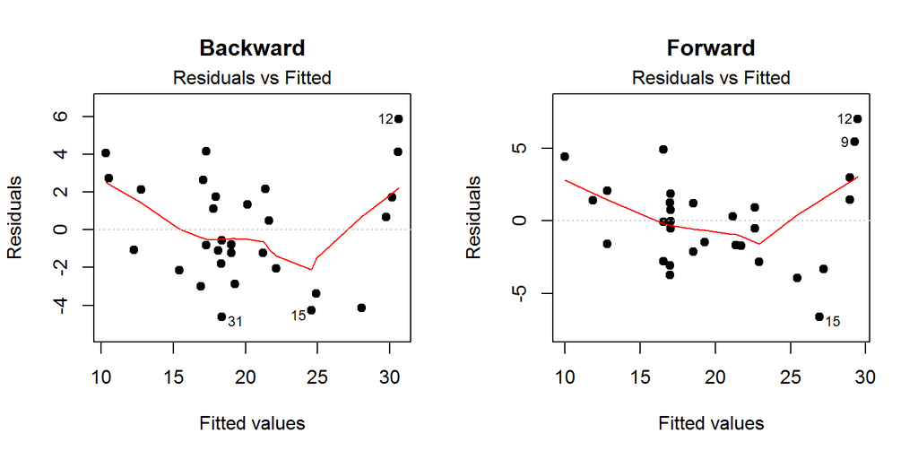

```r
par(mfrow=c(1, 2))
plot(modback, main="Backward", pch=19, cex=1, which=1)
plot(modforw, main="Forward", pch=19, cex=1, which=1)
```

### Tarea

1. ¿Qué patrón observa en los gráficos?
2. Para cada uno de los dos modelos incluya términos cuadráticos con el objetivo de incluir ese patrón cuadrático no explicado y mostrado en los gráficos de residuales anteriores.